https://eshanley.github.io/

https://github.com/eshanley

# Final Tutorial: Impact of Food Access on Overall Community Health

## Analysis by Erin Shanley

### Data Source

USDA Food Access Research Atlas: https://www.ers.usda.gov/data-products/food-access-research-atlas/download-the-data/

University of Wisconsin Population Health Institute: 2010 County Health Rankings National Data https://www.countyhealthrankings.org/sites/default/files/2010%20County%20Health%20Rankings%20National%20Data_v2.xls

### Project Explanation and Plan

Since I am a graduate student, to fulfill the extra requirement I will be working alone on this project. The data sets I plan on working with come from the US Department of Agriculture and The University of Wisconsin Population Health Institute. The particular sets of data I will look at focuses on food access across the US and contains information on different counties in the US and their ability to access supermarkets, other healthy and affordable food sources, overall mental health, physical health, and obsesity rates.

While there are many ways to define which areas are considered "food deserts" and many ways to measure food store access for individuals and for neighborhoods, I have chosen a few initial parameters to begin analyzing. I will focus on distance between housing units and grocery stores, frequency of grocery stores, frequency of fast food restaurants, average income rates by county, access to transportation, and obesity rates by county. The data provides a spatial overview of food access indicators for low income vs other census tracts using measures of 1-mile, 10-mile and 20-mile demarcations to the nearest supermarket, and vehicle availability for all census tracts.

### Questions to Address

1. Does the distance between housing units and supermarkets and the frequency of supermarkets in a community impact general health, mental and physical?
2. Do average income rates of a particular county impact overall health of the communities members?
3. Does access to transportation have an impact on a community's general health, mental and physical?
4. Do higher frequencies of fast food restaurants contribute to higher obesity rates in communities?
5. Is there higher or lower rates of obesity in areas with less access to healthy affordable food options?

### Reading in Data

#### USDA Food Access Research Atlas Data

Note that this data refers to the 2010 census.

```python
# Read in neccessary libraries
import numpy as np
import pandas as pd
import matplotlib
import matplotlib.pyplot as plt
```

```python
df_food = pd.read_csv("USDA_data.csv")
df_food.head()
```

|  | CensusTract | State | County | Urban | POP2010 | OHU2010 | GroupQuartersFlag | NUMGQTRS | PCTGQTRS | LILATracts_1And10 | ... | TractSeniors | TractWhite | TractBlack | TractAsian | TractNHOPI | TractAIAN | TractOMultir | TractHispanic | TractHUNV | TractSNAP |
| --- | --- | --- | --- | --- | --- | --- | --- | --- | --- | --- | --- | --- | --- | --- | --- | --- | --- | --- | --- | --- | --- |
| 0 | 1001020100 | Alabama | Autauga | 1 | 1912 | 693 | 0 | 0 | 0.000000 | 0 | ... | 221 | 1622 | 217 | 14 | 0 | 14 | 45 | 44 | 26 | 112 |
| 1 | 1001020200 | Alabama | Autauga | 1 | 2170 | 743 | 0 | 181 | 0.083410 | 0 | ... | 214 | 888 | 1217 | 5 | 0 | 5 | 55 | 75 | 87 | 202 |
| 2 | 1001020300 | Alabama | Autauga | 1 | 3373 | 1256 | 0 | 0 | 0.000000 | 0 | ... | 439 | 2576 | 647 | 17 | 5 | 11 | 117 | 87 | 108 | 120 |
| 3 | 1001020400 | Alabama | Autauga | 1 | 4386 | 1722 | 0 | 0 | 0.000000 | 0 | ... | 904 | 4086 | 193 | 18 | 4 | 11 | 74 | 85 | 19 | 82 |
| 4 | 1001020500 | Alabama | Autauga | 1 | 10766 | 4082 | 0 | 181 | 0.016812 | 0 | ... | 1126 | 8666 | 1437 | 296 | 9 | 48 | 310 | 355 | 198 | 488 |

5 rows × 147 columns

Next, we need to tidy the data imported from the USDA Food Access Research Atlas. Below is a tidied dataframe with columns named more appropriately and unneccessary columns of data removed. This new dataframe displays data surrounding county population, total number of housing units, number of houses without vehicle access, median household income, poverty rate, and access to food of houses at 1 mile, 10 miles, and 20 miles from a grocery store.

```python
# Tidy data by creating new dataframe containing only the relevant parameters
df_food = df_food[["State","County","POP2010",
      "OHU2010",
      "PovertyRate",
      "MedianFamilyIncome",
      "CensusTract",
      "lapop1share","lapop10share","lapop20share","TractHUNV", "LATracts1","LATracts10","LATracts20"]]

df_food.rename(columns={"POP2010": "Population", "OHU2010": "TotalHouseUnits","TractHUNV":"HouseUnitsNoVehicle"}, inplace=True)

display(df_food.head())
df_food.dtypes

#Change data types to proper format
df_food.astype({'LATracts1': 'object','LATracts10': 'object','LATracts20': 'object'}).dtypes
```

|  | State | County | Population | TotalHouseUnits | PovertyRate | MedianFamilyIncome | CensusTract | lapop1share | lapop10share | lapop20share | HouseUnitsNoVehicle | LATracts1 | LATracts10 | LATracts20 |
| --- | --- | --- | --- | --- | --- | --- | --- | --- | --- | --- | --- | --- | --- | --- |
| 0 | Alabama | Autauga | 1912 | 693 | 10.0 | 74750 | 1001020100 | 0.709980 | 0.0 | 0.0 | 26 | 1 | 0 | 0 |
| 1 | Alabama | Autauga | 2170 | 743 | 18.2 | 51875 | 1001020200 | 0.222779 | 0.0 | 0.0 | 87 | 0 | 0 | 0 |
| 2 | Alabama | Autauga | 3373 | 1256 | 19.1 | 52905 | 1001020300 | 0.420360 | 0.0 | 0.0 | 108 | 1 | 0 | 0 |
| 3 | Alabama | Autauga | 4386 | 1722 | 3.3 | 68079 | 1001020400 | 0.310868 | 0.0 | 0.0 | 19 | 1 | 0 | 0 |
| 4 | Alabama | Autauga | 10766 | 4082 | 8.5 | 77819 | 1001020500 | 0.245504 | 0.0 | 0.0 | 198 | 1 | 0 | 0 |

```
State                   object
County                  object
Population               int64
TotalHouseUnits          int64
PovertyRate            float64
MedianFamilyIncome       int64
CensusTract              int64
lapop1share            float64
lapop10share           float64
lapop20share           float64
HouseUnitsNoVehicle      int64
LATracts1               object
LATracts10              object
LATracts20              object
dtype: object
```

Below I have created a pivot table indexed on state and county to organize the above dataframe into a more manageable format.

```python
# Create a pivot table to organize data by State and County
df_food_pivot = df_food.pivot_table(values=['Population','TotalHouseUnits','PovertyRate','MedianFamilyIncome','lapop1share',
                                            'lapop10share','lapop20share','HouseUnitsNoVehicle','LATracts1','LATracts10','LATracts20'],
                                   index=['State','County'],
                                   aggfunc={'Population':np.sum,'TotalHouseUnits':np.sum,'HouseUnitsNoVehicle':np.sum, 'PovertyRate':np.mean,'MedianFamilyIncome':np.mean,'lapop1share':np.mean,
                                            'lapop10share':np.mean,'lapop20share':np.mean,'LATracts1':np.mean,'LATracts10':np.mean,'LATracts20':np.mean})
df_food_pivot.round(2)
```

| State | County | HouseUnitsNoVehicle | LATracts1 | LATracts10 | LATracts20 | MedianFamilyIncome | Population | PovertyRate | TotalHouseUnits | lapop10share | lapop1share | lapop20share |
| --- | --- | --- | --- | --- | --- | --- | --- | --- | --- | --- | --- | --- |
| Alabama | Autauga | 1081 | 0.50 | 0.25 | 0.00 | 61082.92 | 54571 | 13.86 | 20221 | 0.16 | 0.67 | 0.00 |
|  | Baldwin | 2242 | 0.42 | 0.06 | 0.00 | 60664.94 | 182265 | 14.36 | 73180 | 0.04 | 0.74 | 0.00 |
|  | Barbour | 802 | 0.22 | 0.33 | 0.00 | 43123.00 | 27457 | 24.53 | 9820 | 0.18 | 0.68 | 0.00 |
|  | Bibb | 299 | 0.00 | 0.00 | 0.00 | 43362.50 | 22915 | 16.02 | 7953 | 0.01 | 0.88 | 0.00 |
|  | Blount | 823 | 0.11 | 0.11 | 0.00 | 52136.00 | 57322 | 17.91 | 21578 | 0.03 | 0.92 | 0.00 |
| ... | ... | ... | ... | ... | ... | ... | ... | ... | ... | ... | ... | ... |
| Wyoming | Sweetwater | 628 | 0.33 | 0.08 | 0.08 | 81835.08 | 43806 | 11.84 | 16475 | 0.09 | 0.55 | 0.08 |
|  | Teton | 143 | 0.25 | 0.25 | 0.25 | 89555.25 | 21294 | 8.10 | 8973 | 0.09 | 0.78 | 0.03 |
|  | Uinta | 264 | 0.00 | 0.00 | 0.00 | 65312.67 | 21118 | 14.17 | 7668 | 0.03 | 0.60 | 0.00 |
|  | Washakie | 252 | 0.00 | 0.33 | 0.33 | 62213.67 | 8533 | 14.13 | 3492 | 0.09 | 0.29 | 0.07 |
|  | Weston | 203 | 0.50 | 0.50 | 0.00 | 75233.00 | 7208 | 12.10 | 3021 | 0.13 | 0.52 | 0.03 |

3141 rows × 11 columns

I decided to only use a fraction of the parameters available in this dataset to start and make the data more manageable. I find these parameters including, census tract number, state, county, population count, count of housing units, poverty rate, median family income, low access population at 1 mile, 10 miles, and 20 miles, and vehicle access, to be the most useful at this point. I formatted the dataframe to be grouped by state and county.

#### County Health Data

```python
# Read in data from University of Wisconsin Population Health Institute
df_health = pd.read_csv("County_Health.csv", header=[1])

# Calculate the percentage of premature deaths from the overall population of each county
df_health['% Premature Deaths'] = df_health.Deaths/df_health['Aggregate Population']

# Select columns to keep in dataframe
df_health = df_health[['State','County','Aggregate Population','% Premature Deaths','% Fair/Poor',
                       'Physically Unhealthy Days','Mentally Unhealthy Days','% Smokers','% Obese','% Uninsured',
                       '% unemployed','% Children in Poverty','GINI','% Healthy Food']]
df_health.rename(columns={'% Fair/Poor':'% Fair/Poor Health',
                          '% Healthy Food':'% of Zip Codes with Healthy Food Access',
                          'GINI':'Gini coefficient of household income inequality'}, inplace= True)
display(df_health)
df_health.dtypes
```

|  | State | County | Aggregate Population | % Premature Deaths | % Fair/Poor Health | Physically Unhealthy Days | Mentally Unhealthy Days | % Smokers | % Obese | % Uninsured | % unemployed | % Children in Poverty | Gini coefficient of household income inequality | % of Zip Codes with Healthy Food Access |
| --- | --- | --- | --- | --- | --- | --- | --- | --- | --- | --- | --- | --- | --- | --- |
| 0 | Alabama | Autauga | 137881.0 | 0.004859 | 26.0 | 5.5 | 4.1 | 28.0 | 30.0 | 14.0 | 5.0 | 14.0 | 41.0 | 25.0 |
| 1 | Alabama | Baldwin | 449589.0 | 0.004778 | 13.0 | 3.6 | 4.1 | 23.0 | 25.0 | 21.0 | 4.0 | 15.0 | 45.0 | 42.0 |
| 2 | Alabama | Barbour | 79450.0 | 0.005337 | 24.0 | 6.1 | 3.8 | 23.0 | 36.0 | 15.0 | 8.0 | 34.0 | 47.0 | 40.0 |
| 3 | Alabama | Bibb | 60430.0 | 0.006172 | 18.0 | 4.2 | 5.3 | NaN | 32.0 | 18.0 | 5.0 | 24.0 | 40.0 | 50.0 |
| 4 | Alabama | Blount | 155580.0 | 0.005058 | 25.0 | 5.6 | 4.5 | 23.0 | 32.0 | 21.0 | 4.0 | 19.0 | 41.0 | 57.0 |
| ... | ... | ... | ... | ... | ... | ... | ... | ... | ... | ... | ... | ... | ... | ... |
| 3138 | Wyoming | Uinta | 56457.0 | 0.003631 | 16.0 | 4.1 | 3.4 | 21.0 | 30.0 | 14.0 | 3.0 | 12.0 | 37.0 | 29.0 |
| 3139 | Wyoming | Washakie | 21224.0 | 0.004288 | 13.0 | 3.0 | 2.4 | 18.0 | 24.0 | 16.0 | 3.0 | 16.0 | 45.0 | 50.0 |
| 3140 | Wyoming | Weston | 17958.0 | 0.005513 | 16.0 | 3.1 | 3.1 | 23.0 | 29.0 | 17.0 | 3.0 | 12.0 | 43.0 | 50.0 |
| 3141 | NaN | NaN | NaN | NaN | NaN | NaN | NaN | NaN | NaN | NaN | NaN | NaN | NaN | NaN |
| 3142 | NaN | NaN | NaN | NaN | NaN | NaN | NaN | NaN | NaN | NaN | NaN | NaN | NaN | NaN |

3143 rows × 14 columns

```
State                                               object
County                                              object
Aggregate Population                               float64
% Premature Deaths                                 float64
% Fair/Poor Health                                 float64
Physically Unhealthy Days                          float64
Mentally Unhealthy Days                            float64
% Smokers                                          float64
% Obese                                            float64
% Uninsured                                        float64
% unemployed                                       float64
% Children in Poverty                              float64
Gini coefficient of household income inequality    float64
% of Zip Codes with Healthy Food Access            float64
dtype: object
```

I decided to only use a fraction of the parameters available in this dataset to start and make the data more manageable. I find these parameters including, state, county, aggregate population, percentage of premature deaths, percentage of fair/poor health days in a month, count of physically and mentally unhealthy days a month, percent of smokers, percent obese, percent uninsured adults, percent unemployed adults, percent of children in poverty, and percent of zip codes in a given county with access to healthy food, to be the most useful at this point. I formatted the dataframe to be grouped by state and county. Then I created a pivot table to make the data more organized.

```python
# Create pivot table to index by State and County
df_health_pivot = df_health.pivot_table(values=['Aggregate Population',
                                       '% Premature Deaths','% Fair/Poor Health','Physically Unhealthy Days',
                                       'Mentally Unhealthy Days','% Smokers','% Obese','% Uninsured',
                                               '% unemployed','% Children in Poverty','Gini coefficient of household income inequality', '% of Zip Codes with Healthy Food Access'],
                                       index=['State','County'])
display(df_health_pivot)
```

| State | County | % Children in Poverty | % Fair/Poor Health | % Obese | % Premature Deaths | % Smokers | % Uninsured | % of Zip Codes with Healthy Food Access | % unemployed | Aggregate Population | Gini coefficient of household income inequality | Mentally Unhealthy Days | Physically Unhealthy Days |
| --- | --- | --- | --- | --- | --- | --- | --- | --- | --- | --- | --- | --- | --- |
| Alabama | Autauga | 14.0 | 26.0 | 30.0 | 0.004859 | 28.0 | 14.0 | 25.0 | 5.0 | 137881.0 | 41.0 | 4.1 | 5.5 |
|  | Baldwin | 15.0 | 13.0 | 25.0 | 0.004778 | 23.0 | 21.0 | 42.0 | 4.0 | 449589.0 | 45.0 | 4.1 | 3.6 |
|  | Barbour | 34.0 | 24.0 | 36.0 | 0.005337 | 23.0 | 15.0 | 40.0 | 8.0 | 79450.0 | 47.0 | 3.8 | 6.1 |
|  | Bibb | 24.0 | 18.0 | 32.0 | 0.006172 | NaN | 18.0 | 50.0 | 5.0 | 60430.0 | 40.0 | 5.3 | 4.2 |
|  | Blount | 19.0 | 25.0 | 32.0 | 0.005058 | 23.0 | 21.0 | 57.0 | 4.0 | 155580.0 | 41.0 | 4.5 | 5.6 |
| ... | ... | ... | ... | ... | ... | ... | ... | ... | ... | ... | ... | ... | ... |
| Wyoming | Sweetwater | 9.0 | 14.0 | 29.0 | 0.003787 | 28.0 | 16.0 | 17.0 | 3.0 | 107990.0 | 37.0 | 4.0 | 3.6 |
|  | Teton | 7.0 | 7.0 | 13.0 | 0.002135 | 13.0 | 25.0 | 25.0 | 3.0 | 56671.0 | 53.0 | 2.3 | 2.7 |
|  | Uinta | 12.0 | 16.0 | 30.0 | 0.003631 | 21.0 | 14.0 | 29.0 | 3.0 | 56457.0 | 37.0 | 3.4 | 4.1 |
|  | Washakie | 16.0 | 13.0 | 24.0 | 0.004288 | 18.0 | 16.0 | 50.0 | 3.0 | 21224.0 | 45.0 | 2.4 | 3.0 |
|  | Weston | 12.0 | 16.0 | 29.0 | 0.005513 | 23.0 | 17.0 | 50.0 | 3.0 | 17958.0 | 43.0 | 3.1 | 3.1 |

3141 rows × 12 columns

#### Combining USDA Food Access Data and County Health Data

```python
# Using .merge() function to combine the two dataframes into one
df = df_food.merge(df_health, left_on=['State','County'], right_on=['State','County'], how='inner')
display(df)
# Create pivot table of new dataframe indexed by 'State' and 'County'
df_pivot = df.pivot_table(values=['Population','TotalHouseUnits','PovertyRate','MedianFamilyIncome','lapop1share',
                                'lapop10share','lapop20share','HouseUnitsNoVehicle','LATracts1','LATracts10','LATracts20',
                                '% Premature Deaths','% Fair/Poor Health','Physically Unhealthy Days','Mentally Unhealthy Days',
                                '% Smokers','% Obese','% Uninsured','% unemployed','% Children in Poverty',
                                'Gini coefficient of household income inequality', '% of Zip Codes with Healthy Food Access'],
                         index=['State','County'])

display(df_pivot.round(2))
```

|  | State | County | Population | TotalHouseUnits | PovertyRate | MedianFamilyIncome | CensusTract | lapop1share | lapop10share | lapop20share | ... | % Fair/Poor Health | Physically Unhealthy Days | Mentally Unhealthy Days | % Smokers | % Obese | % Uninsured | % unemployed | % Children in Poverty | Gini coefficient of household income inequality | % of Zip Codes with Healthy Food Access |
| --- | --- | --- | --- | --- | --- | --- | --- | --- | --- | --- | --- | --- | --- | --- | --- | --- | --- | --- | --- | --- | --- |
| 0 | Alabama | Autauga | 1912 | 693 | 10.0 | 74750 | 1001020100 | 0.709980 | 0.000000 | 0.000000 | ... | 26.0 | 5.5 | 4.1 | 28.0 | 30.0 | 14.0 | 5.0 | 14.0 | 41.0 | 25.0 |
| 1 | Alabama | Autauga | 2170 | 743 | 18.2 | 51875 | 1001020200 | 0.222779 | 0.000000 | 0.000000 | ... | 26.0 | 5.5 | 4.1 | 28.0 | 30.0 | 14.0 | 5.0 | 14.0 | 41.0 | 25.0 |
| 2 | Alabama | Autauga | 3373 | 1256 | 19.1 | 52905 | 1001020300 | 0.420360 | 0.000000 | 0.000000 | ... | 26.0 | 5.5 | 4.1 | 28.0 | 30.0 | 14.0 | 5.0 | 14.0 | 41.0 | 25.0 |
| 3 | Alabama | Autauga | 4386 | 1722 | 3.3 | 68079 | 1001020400 | 0.310868 | 0.000000 | 0.000000 | ... | 26.0 | 5.5 | 4.1 | 28.0 | 30.0 | 14.0 | 5.0 | 14.0 | 41.0 | 25.0 |
| 4 | Alabama | Autauga | 10766 | 4082 | 8.5 | 77819 | 1001020500 | 0.245504 | 0.000000 | 0.000000 | ... | 26.0 | 5.5 | 4.1 | 28.0 | 30.0 | 14.0 | 5.0 | 14.0 | 41.0 | 25.0 |
| ... | ... | ... | ... | ... | ... | ... | ... | ... | ... | ... | ... | ... | ... | ... | ... | ... | ... | ... | ... | ... | ... |
| 72822 | Wyoming | Washakie | 3326 | 1317 | 15.2 | 67917 | 56043000200 | 0.815997 | 0.271169 | 0.219503 | ... | 13.0 | 3.0 | 2.4 | 18.0 | 24.0 | 16.0 | 3.0 | 16.0 | 45.0 | 50.0 |
| 72823 | Wyoming | Washakie | 2665 | 1154 | 14.5 | 52474 | 56043000301 | 0.000000 | 0.000000 | 0.000000 | ... | 13.0 | 3.0 | 2.4 | 18.0 | 24.0 | 16.0 | 3.0 | 16.0 | 45.0 | 50.0 |
| 72824 | Wyoming | Washakie | 2542 | 1021 | 12.7 | 66250 | 56043000302 | 0.061109 | 0.000000 | 0.000000 | ... | 13.0 | 3.0 | 2.4 | 18.0 | 24.0 | 16.0 | 3.0 | 16.0 | 45.0 | 50.0 |
| 72825 | Wyoming | Weston | 3314 | 1322 | 9.2 | 81500 | 56045951100 | 0.688747 | 0.256337 | 0.056849 | ... | 16.0 | 3.1 | 3.1 | 23.0 | 29.0 | 17.0 | 3.0 | 12.0 | 43.0 | 50.0 |
| 72826 | Wyoming | Weston | 3894 | 1699 | 15.0 | 68966 | 56045951300 | 0.353439 | 0.000000 | 0.000000 | ... | 16.0 | 3.1 | 3.1 | 23.0 | 29.0 | 17.0 | 3.0 | 12.0 | 43.0 | 50.0 |

72827 rows × 26 columns

| State | County | % Children in Poverty | % Fair/Poor Health | % Obese | % Premature Deaths | % Smokers | % Uninsured | % of Zip Codes with Healthy Food Access | % unemployed | Gini coefficient of household income inequality | HouseUnitsNoVehicle | ... | LATracts20 | MedianFamilyIncome | Mentally Unhealthy Days | Physically Unhealthy Days | Population | PovertyRate | TotalHouseUnits | lapop10share | lapop1share | lapop20share |
| --- | --- | --- | --- | --- | --- | --- | --- | --- | --- | --- | --- | --- | --- | --- | --- | --- | --- | --- | --- | --- | --- | --- |
| Alabama | Autauga | 14.0 | 26.0 | 30.0 | 0.00 | 28.0 | 14.0 | 25.0 | 5.0 | 41.0 | 90.08 | ... | 0.00 | 61082.92 | 4.1 | 5.5 | 4547.58 | 13.86 | 1685.08 | 0.16 | 0.67 | 0.00 |
|  | Baldwin | 15.0 | 13.0 | 25.0 | 0.00 | 23.0 | 21.0 | 42.0 | 4.0 | 45.0 | 72.32 | ... | 0.00 | 60664.94 | 4.1 | 3.6 | 5879.52 | 14.36 | 2360.65 | 0.04 | 0.74 | 0.00 |
|  | Barbour | 34.0 | 24.0 | 36.0 | 0.01 | 23.0 | 15.0 | 40.0 | 8.0 | 47.0 | 89.11 | ... | 0.00 | 43123.00 | 3.8 | 6.1 | 3050.78 | 24.53 | 1091.11 | 0.18 | 0.68 | 0.00 |
|  | Bibb | 24.0 | 18.0 | 32.0 | 0.01 | NaN | 18.0 | 50.0 | 5.0 | 40.0 | 74.75 | ... | 0.00 | 43362.50 | 5.3 | 4.2 | 5728.75 | 16.02 | 1988.25 | 0.01 | 0.88 | 0.00 |
|  | Blount | 19.0 | 25.0 | 32.0 | 0.01 | 23.0 | 21.0 | 57.0 | 4.0 | 41.0 | 91.44 | ... | 0.00 | 52136.00 | 4.5 | 5.6 | 6369.11 | 17.91 | 2397.56 | 0.03 | 0.92 | 0.00 |
| ... | ... | ... | ... | ... | ... | ... | ... | ... | ... | ... | ... | ... | ... | ... | ... | ... | ... | ... | ... | ... | ... | ... |
| Wyoming | Sweetwater | 9.0 | 14.0 | 29.0 | 0.00 | 28.0 | 16.0 | 17.0 | 3.0 | 37.0 | 52.33 | ... | 0.08 | 81835.08 | 4.0 | 3.6 | 3650.50 | 11.84 | 1372.92 | 0.09 | 0.55 | 0.08 |
|  | Teton | 7.0 | 7.0 | 13.0 | 0.00 | 13.0 | 25.0 | 25.0 | 3.0 | 53.0 | 35.75 | ... | 0.25 | 89555.25 | 2.3 | 2.7 | 5323.50 | 8.10 | 2243.25 | 0.09 | 0.78 | 0.03 |
|  | Uinta | 12.0 | 16.0 | 30.0 | 0.00 | 21.0 | 14.0 | 29.0 | 3.0 | 37.0 | 88.00 | ... | 0.00 | 65312.67 | 3.4 | 4.1 | 7039.33 | 14.17 | 2556.00 | 0.03 | 0.60 | 0.00 |
|  | Washakie | 16.0 | 13.0 | 24.0 | 0.00 | 18.0 | 16.0 | 50.0 | 3.0 | 45.0 | 84.00 | ... | 0.33 | 62213.67 | 2.4 | 3.0 | 2844.33 | 14.13 | 1164.00 | 0.09 | 0.29 | 0.07 |
|  | Weston | 12.0 | 16.0 | 29.0 | 0.01 | 23.0 | 17.0 | 50.0 | 3.0 | 43.0 | 101.50 | ... | 0.00 | 75233.00 | 3.1 | 3.1 | 3604.00 | 12.10 | 1510.50 | 0.13 | 0.52 | 0.03 |

3137 rows × 22 columns

## Exploratory Data Analysis

To get a general understanding of our data and identify which parameters have the largest effect on a communities overall health, I decided to create a correlation matrix of all of the parameters when relating to obesity rates and a combined overall unhealthy days parameter that I created from the data presenting the average number of unhealthy days an individual reported per month in each county. The overall unhealthy days parameter is calculated as the sum of the average physically unhealthy days per month and the average mentally unhealthy days per month of an individual, divided by 30 to get the percentage of the month an individual is mentally and/or physicallly unhealthy.

First, lets look at which parameters have the greatest correlation when using obesity rate as an indicator of community overall health.

```python
# Find correlation between each variable and obesity rates
corr_df = df_pivot.corr()
display(corr_df)

# Display the correlation values in order in a bar graph
obesity_corr_df = corr_df[['% Obese']]["% Obese"]
obesity_corr_df = obesity_corr_df.drop('% Obese')
obesity_corr_df = obesity_corr_df.sort_values()

# Choose the greatest correlation parameters from all parameters considered
greatest_obesity_corr_df = obesity_corr_df[(obesity_corr_df >= .3) | (obesity_corr_df <= -.3)]
greatest_obesity_corr_df = greatest_obesity_corr_df.sort_values()
```

|  | % Children in Poverty | % Fair/Poor Health | % Obese | % Premature Deaths | % Smokers | % Uninsured | % of Zip Codes with Healthy Food Access | % unemployed | Gini coefficient of household income inequality | HouseUnitsNoVehicle | ... | LATracts20 | MedianFamilyIncome | Mentally Unhealthy Days | Physically Unhealthy Days | Population | PovertyRate | TotalHouseUnits | lapop10share | lapop1share | lapop20share |
| --- | --- | --- | --- | --- | --- | --- | --- | --- | --- | --- | --- | --- | --- | --- | --- | --- | --- | --- | --- | --- | --- |
| % Children in Poverty | 1.000000 | 0.665417 | 0.455924 | 0.656805 | 0.393383 | 0.221392 | -0.127544 | 0.409918 | 0.590692 | 0.241894 | ... | 0.066184 | -0.752778 | 0.371574 | 0.506382 | -0.166353 | 0.806606 | -0.202262 | 0.123000 | 0.216121 | 0.056926 |
| % Fair/Poor Health | 0.665417 | 1.000000 | 0.484557 | 0.602935 | 0.551725 | 0.121509 | -0.037910 | 0.423604 | 0.375027 | 0.226371 | ... | -0.113987 | -0.600189 | 0.600930 | 0.760157 | 0.084667 | 0.599408 | 0.046115 | -0.117565 | 0.254140 | -0.118584 |
| % Obese | 0.455924 | 0.484557 | 1.000000 | 0.479977 | 0.415832 | -0.175663 | -0.040832 | 0.310946 | 0.104382 | 0.110621 | ... | -0.068732 | -0.493518 | 0.250547 | 0.334227 | -0.022880 | 0.427828 | -0.069152 | 0.000375 | 0.276893 | -0.069438 |
| % Premature Deaths | 0.656805 | 0.602935 | 0.479977 | 1.000000 | 0.489173 | 0.107648 | -0.091722 | 0.320594 | 0.378045 | 0.083774 | ... | 0.041281 | -0.652002 | 0.423216 | 0.524550 | -0.260361 | 0.496759 | -0.194954 | 0.148956 | 0.359541 | 0.041276 |
| % Smokers | 0.393383 | 0.551725 | 0.415832 | 0.489173 | 1.000000 | -0.121589 | -0.058353 | 0.327086 | 0.093037 | 0.180977 | ... | -0.072662 | -0.427333 | 0.480469 | 0.515111 | 0.038711 | 0.346337 | 0.049135 | -0.120198 | 0.253502 | -0.065299 |
| % Uninsured | 0.221392 | 0.121509 | -0.175663 | 0.107648 | -0.121589 | 1.000000 | -0.061570 | -0.226847 | 0.302200 | -0.212884 | ... | 0.290082 | -0.144135 | -0.009750 | 0.032774 | -0.153187 | 0.102605 | -0.198343 | 0.371893 | 0.163441 | 0.310809 |
| % of Zip Codes with Healthy Food Access | -0.127544 | -0.037910 | -0.040832 | -0.091722 | -0.058353 | -0.061570 | 1.000000 | 0.087439 | -0.041349 | 0.091045 | ... | -0.126202 | 0.127911 | -0.004419 | -0.006827 | 0.201068 | -0.071389 | 0.191322 | -0.235111 | -0.227618 | -0.115151 |
| % unemployed | 0.409918 | 0.423604 | 0.310946 | 0.320594 | 0.327086 | -0.226847 | 0.087439 | 1.000000 | 0.148633 | 0.291109 | ... | -0.125944 | -0.424969 | 0.317935 | 0.358755 | 0.087171 | 0.448819 | 0.061914 | -0.178047 | 0.151978 | -0.127053 |
| Gini coefficient of household income inequality | 0.590692 | 0.375027 | 0.104382 | 0.378045 | 0.093037 | 0.302200 | -0.041349 | 0.148633 | 1.000000 | 0.252595 | ... | -0.002938 | -0.337301 | 0.237074 | 0.273442 | -0.116097 | 0.557075 | -0.100925 | 0.021875 | -0.062528 | -0.004759 |
| HouseUnitsNoVehicle | 0.241894 | 0.226371 | 0.110621 | 0.083774 | 0.180977 | -0.212884 | 0.091045 | 0.291109 | 0.252595 | 1.000000 | ... | -0.107274 | -0.099369 | 0.148432 | 0.162227 | 0.301199 | 0.345858 | 0.295434 | -0.235492 | -0.231348 | -0.129898 |
| LATracts1 | -0.212825 | -0.119171 | -0.115467 | -0.305422 | -0.050127 | -0.212196 | 0.182402 | -0.039559 | -0.048908 | 0.106485 | ... | -0.204277 | 0.243787 | -0.032212 | -0.091381 | 0.419272 | -0.052801 | 0.388433 | -0.390217 | -0.387657 | -0.210030 |
| LATracts10 | 0.135091 | -0.086349 | 0.033835 | 0.156126 | -0.111047 | 0.348385 | -0.266485 | -0.173394 | 0.028944 | -0.213248 | ... | 0.540190 | -0.124882 | -0.191834 | -0.130467 | -0.381691 | -0.032635 | -0.382075 | 0.847125 | 0.406729 | 0.532144 |
| LATracts20 | 0.066184 | -0.113987 | -0.068732 | 0.041281 | -0.072662 | 0.290082 | -0.126202 | -0.125944 | -0.002938 | -0.107274 | ... | 1.000000 | -0.001076 | -0.140427 | -0.129772 | -0.315272 | -0.048895 | -0.339007 | 0.733838 | 0.274985 | 0.909888 |
| MedianFamilyIncome | -0.752778 | -0.600189 | -0.493518 | -0.652002 | -0.427333 | -0.144135 | 0.127911 | -0.424969 | -0.337301 | -0.099369 | ... | -0.001076 | 1.000000 | -0.353888 | -0.474926 | 0.137826 | -0.693062 | 0.137006 | -0.085407 | -0.312916 | 0.008778 |
| Mentally Unhealthy Days | 0.371574 | 0.600930 | 0.250547 | 0.423216 | 0.480469 | -0.009750 | -0.004419 | 0.317935 | 0.237074 | 0.148432 | ... | -0.140427 | -0.353888 | 1.000000 | 0.624982 | 0.130335 | 0.360869 | 0.144124 | -0.218316 | 0.127047 | -0.165963 |
| Physically Unhealthy Days | 0.506382 | 0.760157 | 0.334227 | 0.524550 | 0.515111 | 0.032774 | -0.006827 | 0.358755 | 0.273442 | 0.162227 | ... | -0.129772 | -0.474926 | 0.624982 | 1.000000 | 0.082033 | 0.457638 | 0.083550 | -0.146803 | 0.235583 | -0.137005 |
| Population | -0.166353 | 0.084667 | -0.022880 | -0.260361 | 0.038711 | -0.153187 | 0.201068 | 0.087171 | -0.116097 | 0.301199 | ... | -0.315272 | 0.137826 | 0.130335 | 0.082033 | 1.000000 | 0.022956 | 0.950432 | -0.511798 | -0.154651 | -0.372339 |
| PovertyRate | 0.806606 | 0.599408 | 0.427828 | 0.496759 | 0.346337 | 0.102605 | -0.071389 | 0.448819 | 0.557075 | 0.345858 | ... | -0.048895 | -0.693062 | 0.360869 | 0.457638 | 0.022956 | 1.000000 | -0.021285 | -0.046223 | 0.075200 | -0.057221 |
| TotalHouseUnits | -0.202262 | 0.046115 | -0.069152 | -0.194954 | 0.049135 | -0.198343 | 0.191322 | 0.061914 | -0.100925 | 0.295434 | ... | -0.339007 | 0.137006 | 0.144124 | 0.083550 | 0.950432 | -0.021285 | 1.000000 | -0.525800 | -0.147303 | -0.397496 |
| lapop10share | 0.123000 | -0.117565 | 0.000375 | 0.148956 | -0.120198 | 0.371893 | -0.235111 | -0.178047 | 0.021875 | -0.235492 | ... | 0.733838 | -0.085407 | -0.218316 | -0.146803 | -0.511798 | -0.046223 | -0.525800 | 1.000000 | 0.439729 | 0.768507 |
| lapop1share | 0.216121 | 0.254140 | 0.276893 | 0.359541 | 0.253502 | 0.163441 | -0.227618 | 0.151978 | -0.062528 | -0.231348 | ... | 0.274985 | -0.312916 | 0.127047 | 0.235583 | -0.154651 | 0.075200 | -0.147303 | 0.439729 | 1.000000 | 0.296403 |
| lapop20share | 0.056926 | -0.118584 | -0.069438 | 0.041276 | -0.065299 | 0.310809 | -0.115151 | -0.127053 | -0.004759 | -0.129898 | ... | 0.909888 | 0.008778 | -0.165963 | -0.137005 | -0.372339 | -0.057221 | -0.397496 | 0.768507 | 0.296403 | 1.000000 |

22 rows × 22 columns

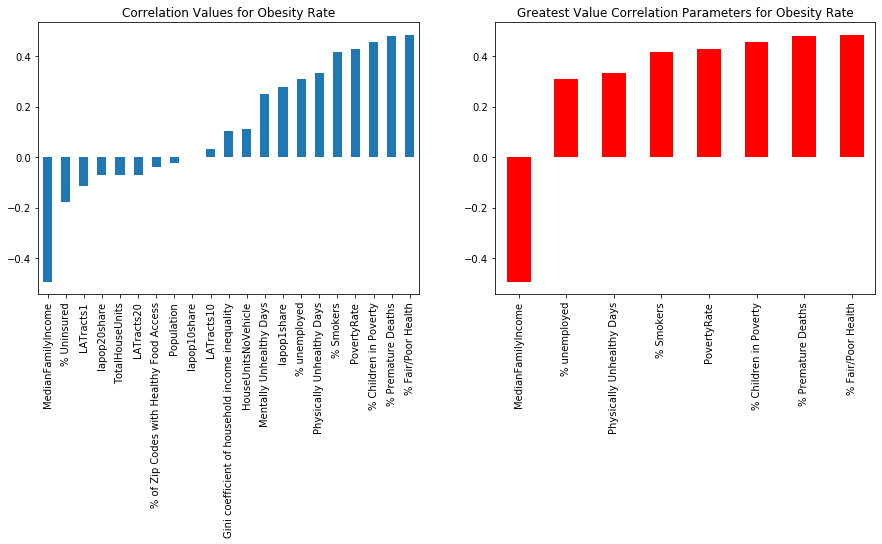

```python
# Plot all correlation values and the greatest correlation value parameters for Obesity rate
fig, ax = plt.subplots(1,2, figsize=(15,5))

obesity_corr_df.plot.bar(title = 'Correlation Values for Obesity Rate',ax=ax[0])
greatest_obesity_corr_df.plot.bar(title = 'Greatest Value Correlation Parameters for Obesity Rate',ax=ax[1], color='red')
```

The two bar graphs above suggest that median family income, the percent of the population that is unemployed, the number of physically unhealthy days, the percent of smokers in a population, the poverty rate, the percent of children in poverty, the percent of premature deaths in a population, and the percentage of individuals that report fair/poor health in a community are the greatest indicators of that community's overall health.

Next let us consider which parameters have the greatest correlation when using combined physically unhealthy and mentally unhealthy days, or the overall unhealthly days parameter as I will now refer to it, as an indicator of community health.

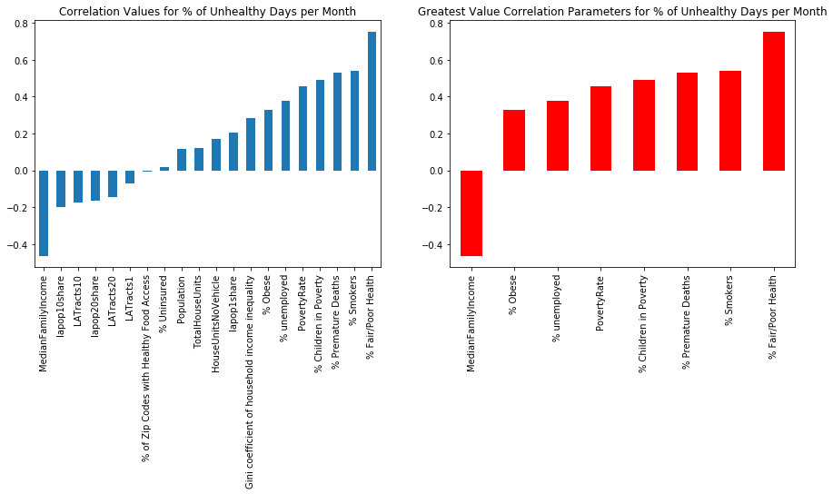

```python
# Create new column to represent the percentage of days people reported unhealthy physically and/or mentally
df_pivot_new = df_pivot
df_pivot_new['% unhealthy days per month'] = (df_pivot['Physically Unhealthy Days']+df_pivot['Mentally Unhealthy Days'])/30


# Find correlation between each variable and the unhealthy days parameter.
corr_df2 = df_pivot_new.corr()
corr_df2 = corr_df2.drop('Physically Unhealthy Days')
corr_df2 = corr_df2.drop('Mentally Unhealthy Days')
unhealthy_days_corr_df = corr_df2[['% unhealthy days per month']]["% unhealthy days per month"]
unhealthy_days_corr_df = unhealthy_days_corr_df.drop('% unhealthy days per month')
unhealthy_days_corr_df = unhealthy_days_corr_df.sort_values()

# Choose the greatest correlation parameters from all parameters considered
greatest_unhealthy_days_corr_df = unhealthy_days_corr_df[(unhealthy_days_corr_df >= .3) | (unhealthy_days_corr_df <= -.3)]
greatest_unhealthy_days_corr_df = greatest_unhealthy_days_corr_df.sort_values()

# Display the correlation values in order in a bar graph
# Plot all correlation values and the greatest correlation value parameters for % unhealthy days per month
fig, ax = plt.subplots(1,2, figsize=(15,5))

unhealthy_days_corr_df.plot.bar(title = 'Correlation Values for % of Unhealthy Days per Month',ax=ax[0])
greatest_unhealthy_days_corr_df.plot.bar(title = 'Greatest Value Correlation Parameters for % of Unhealthy Days per Month',ax=ax[1], color='red')
```

The two bar graphs above suggest that median family income, the percent of the population that is obese, the percent of the population that is unemployed, the poverty rate, the percentage of children in poverty, the percent of premature deaths in a population, the percentage of smokers and the percentage of individuals that report fair/poor health in a community are the greatest indicators of that community's overall health.

Both health indicators, obesity rate and percentage of unhealthy days in a month, suggest that the same parameters have the greatest impact on a community's overall health.

```python
# Create pivot table of median family income and % of zip codes with access to healthy food
df_state = df_pivot[['MedianFamilyIncome','% of Zip Codes with Healthy Food Access']]
df_state = df_state.rename(columns = {'% of Zip Codes with Healthy Food Access':'Healthy Food Access'})

# create list of state names to loop through
state_list = df.State.unique()
```

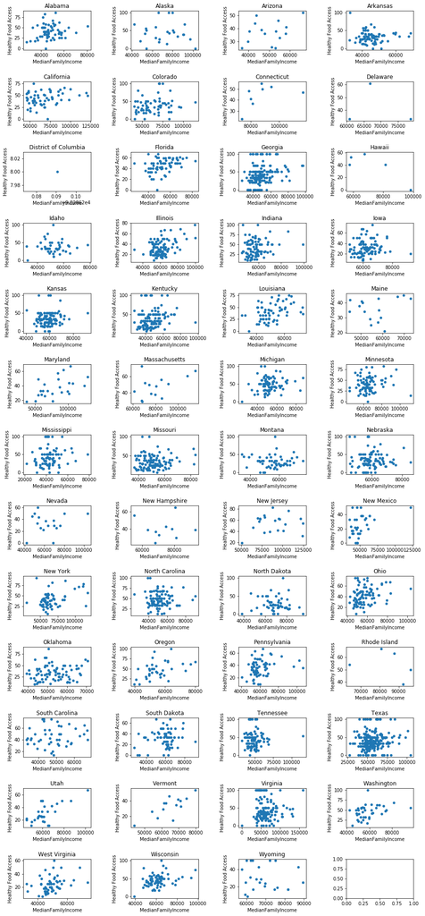

```python
# create subplot to populate
fig, ax = plt.subplots(nrows=13, ncols=4, figsize=(15,35))
plt.subplots_adjust(hspace=0.8)
plt.subplots_adjust(wspace=0.6)

# create subplot of scatter plots of median family income vs healthy food access per state
for i in range(len(state_list)):
    df_state.loc[state_list[i]].plot.scatter(x='MedianFamilyIncome',y='Healthy Food Access',title=state_list[i], ax=ax[i // 4][i % 4])
```

The subplots above show the relationship been median family income and access to healthy food per state. Each dot on the scatter plots represents a county in that given state. These graphs are useful in visualizing whether or not there is a relationship between a household's income and their access to healthy food.

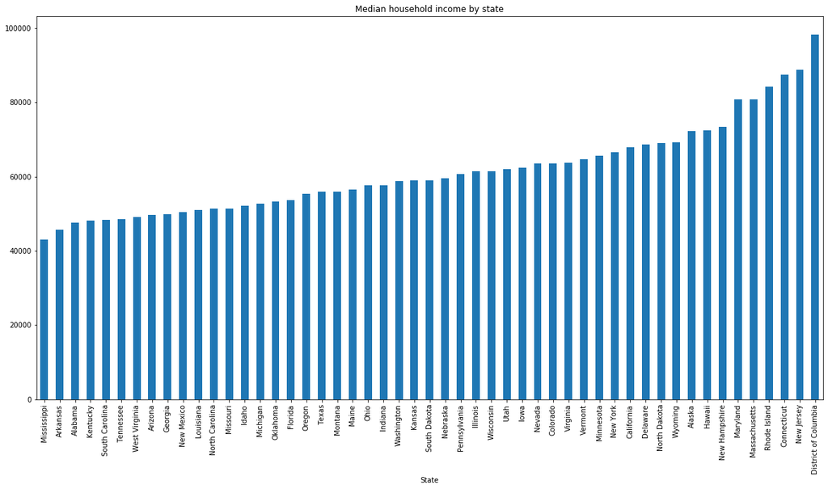

```python
# Create bar graph showing median household incomes by state
fig, ax = plt.subplots(figsize = (20,10))
ax1 = df_pivot.groupby('State')['MedianFamilyIncome'].mean().sort_values().plot.bar(title = 'Median household income by state')
```

The bar graph above shows the median family income per state. It appears that Missippi and Arkansas have the lowest median income, while Washington D.C. and New Jersey have the highest median family incomes. Next, I will display obesity rates by state.

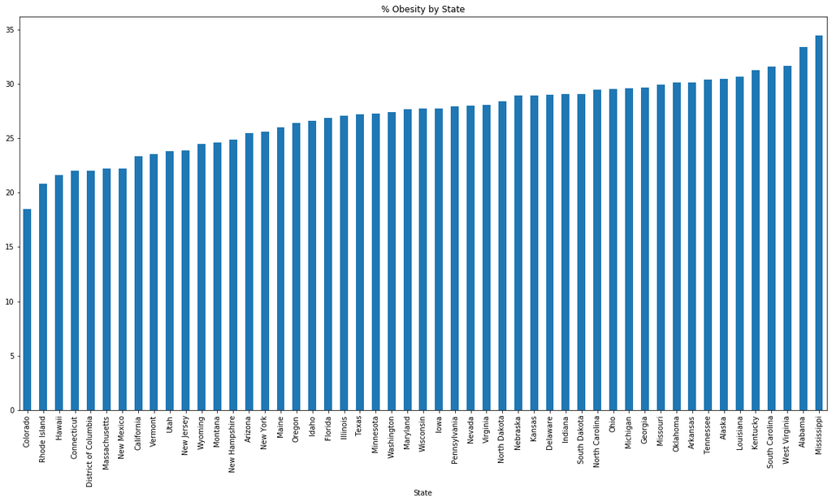

```python
# Create bar graph showing obesity rates by state
fig, ax = plt.subplots(figsize = (20,10))
ax2 = df_pivot.groupby('State')['% Obese'].mean().sort_values().plot.bar(title = '% Obesity by State')
```

The bar graph above reports the rate of obesity by state. This graph shows that Colorado and Rhode Island have the lowest rate of obesity and Alabama and Missippi have the highest rate of obesity.

```python
df_pivot.reset_index(inplace=True)
#df_pivot = df_pivot.rename(columns={'index':'County'})
df_popdist = df_pivot[['County','State','lapop1share','lapop10share','lapop20share','% Obese']]
df_popdist['Obesity Rate']=df_popdist['% Obese']/100
display(df_popdist)
```

|  | County | State | lapop1share | lapop10share | lapop20share | % Obese | Obesity Rate |
| --- | --- | --- | --- | --- | --- | --- | --- |
| 0 | Autauga | Alabama | 0.669629 | 0.160060 | 0.000000 | 30.0 | 0.30 |
| 1 | Baldwin | Alabama | 0.743195 | 0.041243 | 0.000000 | 25.0 | 0.25 |
| 2 | Barbour | Alabama | 0.676481 | 0.183927 | 0.000000 | 36.0 | 0.36 |
| 3 | Bibb | Alabama | 0.879156 | 0.013206 | 0.000000 | 32.0 | 0.32 |
| 4 | Blount | Alabama | 0.918600 | 0.025058 | 0.000000 | 32.0 | 0.32 |
| ... | ... | ... | ... | ... | ... | ... | ... |
| 3132 | Sweetwater | Wyoming | 0.554672 | 0.094768 | 0.076068 | 29.0 | 0.29 |
| 3133 | Teton | Wyoming | 0.776883 | 0.091197 | 0.031089 | 13.0 | 0.13 |
| 3134 | Uinta | Wyoming | 0.595551 | 0.034510 | 0.000645 | 30.0 | 0.30 |
| 3135 | Washakie | Wyoming | 0.292369 | 0.090390 | 0.073168 | 24.0 | 0.24 |
| 3136 | Weston | Wyoming | 0.521093 | 0.128169 | 0.028424 | 29.0 | 0.29 |

3137 rows × 7 columns

Finally, I would like to analyze the effect of average household distance to grocery stores on obesity rate per state.

```python
# Create a pivot table organizing the percentage of a state that lives 1 mile, 10 miles, and 20 miles from a grocery store
    # lapop1share = percentage of population within one mile of a grocery store
    # lapop10share = percentage of population within 10 miles of a grocery store
    # lapop20share = percentage of population within 20 miles of a grocery store

df_popdist_pivot = df_popdist.pivot_table(values=['lapop1share','lapop10share','lapop20share','Obesity Rate'],
                                         index='State',
                                         aggfunc=np.mean)
df_popdist_pivot.round(3)
```

| State | Obesity Rate | lapop10share | lapop1share | lapop20share |
| --- | --- | --- | --- | --- |
| Alabama | 0.334 | 0.096 | 0.735 | 0.000 |
| Alaska | 0.305 | 0.482 | 0.741 | 0.429 |
| Arizona | 0.255 | 0.187 | 0.646 | 0.088 |
| Arkansas | 0.301 | 0.147 | 0.722 | 0.002 |
| California | 0.234 | 0.082 | 0.445 | 0.018 |
| Colorado | 0.185 | 0.182 | 0.587 | 0.066 |
| Connecticut | 0.220 | 0.000 | 0.532 | 0.000 |
| Delaware | 0.290 | 0.000 | 0.470 | 0.000 |
| District of Columbia | 0.220 | 0.000 | 0.022 | 0.000 |
| Florida | 0.269 | 0.060 | 0.610 | 0.001 |
| Georgia | 0.297 | 0.062 | 0.748 | 0.001 |
| Hawaii | 0.216 | 0.032 | 0.606 | 0.013 |
| Idaho | 0.266 | 0.221 | 0.657 | 0.082 |
| Illinois | 0.271 | 0.075 | 0.616 | 0.000 |
| Indiana | 0.291 | 0.025 | 0.634 | 0.000 |
| Iowa | 0.278 | 0.137 | 0.615 | 0.000 |
| Kansas | 0.289 | 0.272 | 0.604 | 0.074 |
| Kentucky | 0.312 | 0.042 | 0.771 | 0.000 |
| Louisiana | 0.307 | 0.093 | 0.639 | 0.003 |
| Maine | 0.260 | 0.048 | 0.721 | 0.003 |
| Maryland | 0.277 | 0.010 | 0.556 | 0.000 |
| Massachusetts | 0.222 | 0.004 | 0.427 | 0.000 |
| Michigan | 0.296 | 0.059 | 0.671 | 0.005 |
| Minnesota | 0.273 | 0.164 | 0.654 | 0.013 |
| Mississippi | 0.345 | 0.112 | 0.725 | 0.000 |
| Missouri | 0.299 | 0.135 | 0.686 | 0.006 |
| Montana | 0.246 | 0.395 | 0.681 | 0.243 |
| Nebraska | 0.289 | 0.350 | 0.658 | 0.121 |
| Nevada | 0.280 | 0.261 | 0.688 | 0.204 |
| New Hampshire | 0.249 | 0.014 | 0.706 | 0.001 |
| New Jersey | 0.239 | 0.001 | 0.388 | 0.000 |
| New Mexico | 0.222 | 0.245 | 0.661 | 0.140 |
| New York | 0.256 | 0.030 | 0.548 | 0.001 |
| North Carolina | 0.295 | 0.030 | 0.710 | 0.003 |
| North Dakota | 0.284 | 0.430 | 0.642 | 0.174 |
| Ohio | 0.296 | 0.024 | 0.619 | 0.000 |
| Oklahoma | 0.301 | 0.223 | 0.685 | 0.032 |
| Oregon | 0.264 | 0.164 | 0.561 | 0.072 |
| Pennsylvania | 0.280 | 0.023 | 0.588 | 0.000 |
| Rhode Island | 0.208 | 0.007 | 0.423 | 0.000 |
| South Carolina | 0.316 | 0.036 | 0.704 | 0.000 |
| South Dakota | 0.291 | 0.460 | 0.736 | 0.195 |
| Tennessee | 0.304 | 0.043 | 0.760 | 0.000 |
| Texas | 0.272 | 0.195 | 0.629 | 0.070 |
| Utah | 0.238 | 0.232 | 0.612 | 0.144 |
| Vermont | 0.236 | 0.056 | 0.764 | 0.000 |
| Virginia | 0.281 | 0.058 | 0.628 | 0.003 |
| Washington | 0.274 | 0.147 | 0.576 | 0.041 |
| West Virginia | 0.317 | 0.079 | 0.731 | 0.001 |
| Wisconsin | 0.277 | 0.085 | 0.657 | 0.001 |
| Wyoming | 0.245 | 0.149 | 0.565 | 0.063 |

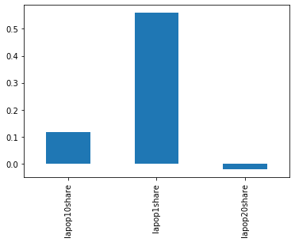

```python
df_popdist_pivot.corr()['Obesity Rate'].drop('Obesity Rate').plot.bar()
```

The above graph shows there is the greatest correlation between obesity rate and households within 1 mile of a grocery store. This data may be skewed however, because most states have the greatest proportion within that category. I need to work towards a better visualization of this data.

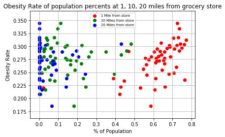

```python
ax=plt.gca()
ax.scatter([df_popdist_pivot['lapop1share']],[df_popdist_pivot['Obesity Rate']],color='r',label='1 Mile from store')
ax.scatter([df_popdist_pivot['lapop10share']],[df_popdist_pivot['Obesity Rate']],color='g',label='10 Miles from store')
ax.scatter([df_popdist_pivot['lapop20share']],[df_popdist_pivot['Obesity Rate']],color='b',label='20 Miles from store')
ax.set(xlabel='% of Population', ylabel='Obesity Rate', title='Obesity Rate of population percents at 1, 10, 20 miles from grocery store')
ax.grid()
ax.legend(loc=9, fontsize='x-small')
```

In the graph above I am trying to show the relationship between distance to a grocery store and obesity. However, it is a bit misleading and not describing exactly what I am aiming for. I will need to ask the TAs for help in finding the best visualization for this data.